# ESM 244 Lab Week 8: Clustering (k-means & hierarchical)

In this lab, you’ll learn how to do some cluster exploration by partition-based (k-means) and hierarchical clustering. You should have already watched the Week 8 lecture so you understand what is happening in each.

## Get & attach required packages

Note: You’ll probably need to install the last 5 packages here for clustering.

```r
library(tidyverse)
library(here)
library(janitor)
library(palmerpenguins)

# Packages for cluster analysis:
library(NbClust)
library(cluster)
library(factoextra)
library(dendextend)
library(ggdendro)
```

## Intro to cluster analysis (k-means, hierarchical)

### Part 1. K-means clustering:

To practice k-means clustering, we’ll use the `penguins` dataset from `palmerpenguins`.

#### Exploratory visualization

First, do some exploratory data visualization, mapping species onto point color. Does it look like there is an opportunity to cluster by species?

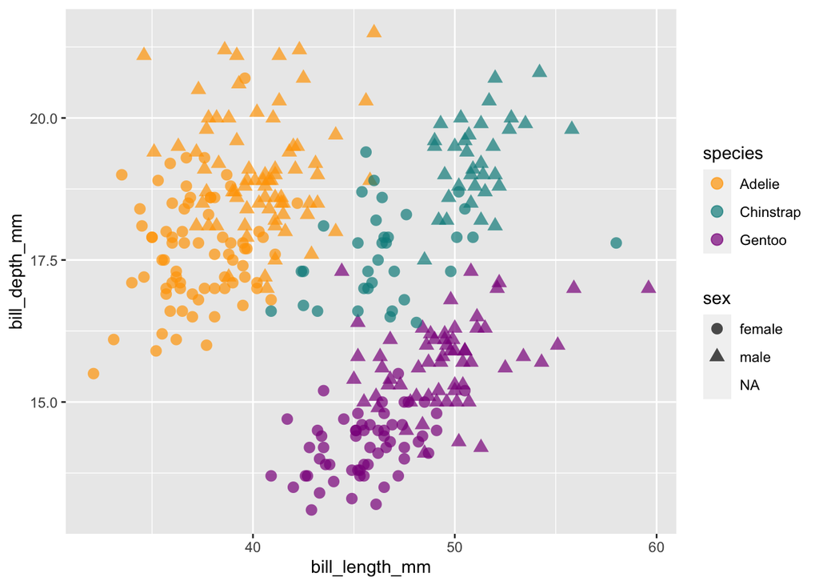

```r
# Bill length versus depth exploratory plot:
ggplot(penguins) +
  geom_point(aes(x = bill_length_mm,
                 y = bill_depth_mm,
                 color = species,
                 shape = sex),
             size = 3,
             alpha = 0.7) +
  scale_color_manual(values = c("orange","cyan4","darkmagenta"))
```

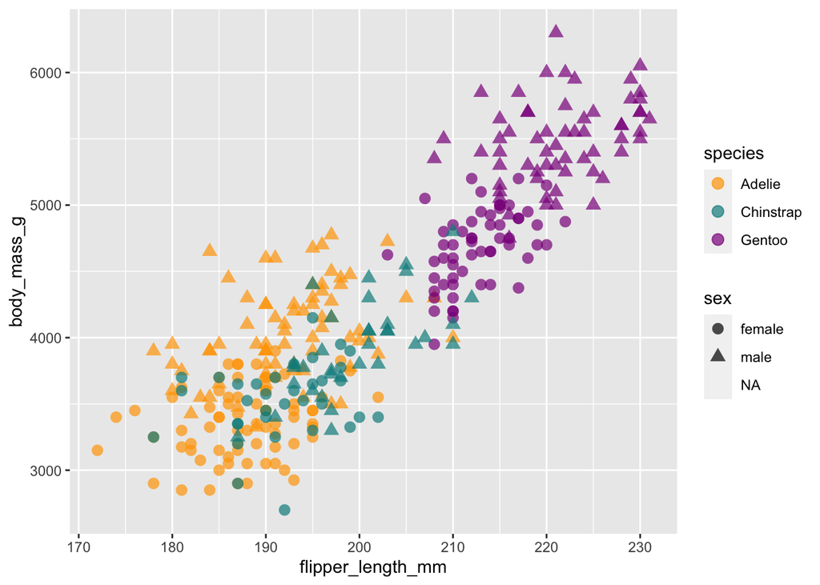

```r
# Flipper length versus body mass exploratory plot:
ggplot(penguins) +
  geom_point(aes(x = flipper_length_mm,
                 y = body_mass_g,
                 color = species,
                 shape = sex),
             size = 3,
             alpha = 0.7) +
  scale_color_manual(values = c("orange","cyan4","darkmagenta"))
```

#### Pick the number of clusters

In the Week 8 lecture, you learned that for k-means clustering you need to specify the number of clusters *a priori*. R **does** have some tools to help you decide, but this should NOT override your judgement based on conceptual or expert understanding.

Here, we use the `NbClust::NbClust()` function, which “provides 30 indices for determining the number of clusters and proposes to user the best clustering scheme from the different results obtained by varying all combinations of number of clusters, distance measures, and clustering methods”. See `?NbClust` for more information.

Basically, it’s going to run 30 different ways of evaluating how many clusters it *thinks* exist, then tell you the breakdown of what they decide (e.g. “8 algorithms think that there should be 4 clusters”).

Note that we’re only using the four structural size measurement variables from `penguins`, which are columns 3 through 6 (hence the `penguins[3:6]` here). We also specify the minimum and maximum number of clusters we want `NbClust` to consider:

```r
# How many clusters do you THINK there should be?
number_est <- NbClust(penguins[3:6], min.nc = 2, max.nc = 10, method = "kmeans")
```

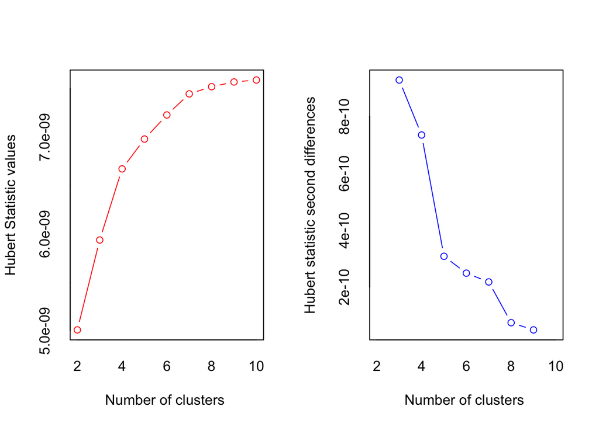

```
## *** : The Hubert index is a graphical method of determining the number of clusters.
##                 In the plot of Hubert index, we seek a significant knee that corresponds to a
##                 significant increase of the value of the measure i.e the significant peak in Hubert
##                 index second differences plot.
##
```

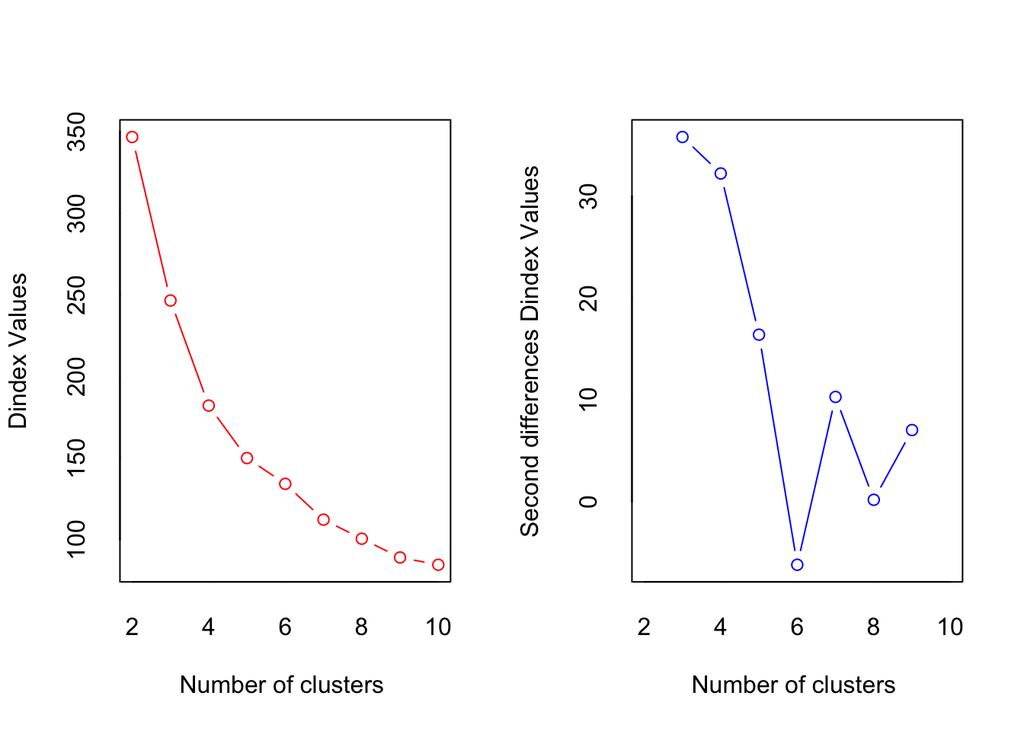

```
## *** : The D index is a graphical method of determining the number of clusters.
##                 In the plot of D index, we seek a significant knee (the significant peak in Dindex
##                 second differences plot) that corresponds to a significant increase of the value of
##                 the measure.
##
## * Among all indices:
## * 8 proposed 2 as the best number of clusters
## * 4 proposed 3 as the best number of clusters
## * 3 proposed 4 as the best number of clusters
## * 1 proposed 5 as the best number of clusters
## * 2 proposed 7 as the best number of clusters
## * 5 proposed 9 as the best number of clusters
## * 1 proposed 10 as the best number of clusters
##
##                    ***** Conclusion *****
##
## * According to the majority rule, the best number of clusters is  2
##
##
```

```r
# Check out the results (just look at the first summary report):
number_est
```

```
## $All.index
##          KL        CH Hartigan     CCC    Scott      Marriot       TrCovW
## 2    4.2442  930.7898 339.4007 60.3272 2863.489 1.505108e+19 8.503304e+14
## 3    1.7929 1096.4356 265.3223 -2.4916 3062.067 1.894886e+19 2.133802e+14
## 4    2.2121 1387.3852 163.0813  2.7050 3290.894 1.725364e+19 6.675599e+13
## 5    2.1473 1578.6734  98.2372  5.6827 3467.347 1.609268e+19 3.049327e+13
## 6    0.7109 1645.8407 149.0231  6.8679 3546.690 1.837535e+19 1.826896e+13
## 7    2.9447 1998.7092  69.3253 10.6394 3680.641 1.690555e+19 8.748022e+12
## 8    0.9685 2071.4083  74.6940 11.4832 3760.053 1.750533e+19 5.980878e+12
## 9  169.1328 2220.4848  18.3320 12.8762 3836.441 1.772039e+19 3.969998e+12
## 10   0.0048 2078.1993  97.9884 11.7599 3852.547 2.087061e+19 3.567812e+12
##      TraceW Friedman     Rubin Cindex     DB Silhouette   Duda Pseudot2   Beale
## 2  58696922 1669.851  106.8518 0.2399 0.6007     0.6296 0.7282  99.2775  0.8967
## 3  29374348 1776.351  213.5153 0.2360 0.6215     0.5650 0.5865 134.6784  1.6912
## 4  16477803 1990.021  380.6256 0.2028 0.6223     0.5531 1.1740 -22.2279 -0.3542
## 5  11114958 2142.536  564.2733 0.1883 0.6176     0.5335 0.5051  54.8755  2.3165
## 6   8606206 2302.842  728.7618 0.2397 0.6495     0.5190 1.0559  -7.1435 -0.1262
## 7   5961953 2612.371 1051.9830 0.2089 0.6230     0.5351 1.0273  -2.8458 -0.0633
## 8   4939722 2866.156 1269.6815 0.1905 0.6191     0.5176 1.1310 -11.1171 -0.2746
## 9   4036925 3238.492 1553.6264 0.1694 0.5938     0.5410 1.1349  -4.7558 -0.2691
## 10  3826284 3288.966 1639.1552 0.1679 0.6021     0.5269 0.5903  22.2076  1.5957
##    Ratkowsky       Ball Ptbiserial    Frey McClain   Dunn Hubert SDindex
## 2     0.4787 29348460.9     0.6992  1.2824  0.2995 0.0139      0  0.0078
## 3     0.4082  9791449.2     0.6451  1.0774  0.4776 0.0179      0  0.0057
## 4     0.3658  4119450.7     0.5836  1.0704  0.6151 0.0210      0  0.0062
## 5     0.3421  2222991.5     0.5358  0.7241  0.7071 0.0240      0  0.0069
## 6     0.3120  1434367.6     0.5229  0.7759  0.7181 0.0335      0  0.0066
## 7     0.2921   851707.6     0.4920  1.7027  0.7397 0.0362      0  0.0081
## 8     0.2742   617465.2     0.4568  0.9652  0.8264 0.0358      0  0.0109
## 9     0.2584   448547.2     0.4333 10.3861  0.8603 0.0360      0  0.0139
## 10    0.2455   382628.4     0.4112  0.4038  0.9593 0.0358      0  0.0229
##      Dindex   SDbw
## 2  346.7122 0.8605
## 3  246.5041 0.7606
## 4  182.1056 0.4503
## 5  149.9349 0.4269
## 6  134.1617 0.3293
## 7  112.1947 0.2043
## 8  100.5131 0.2474
## 9   89.0159 0.2886
```

[output cut: 24 more lines]

```
##                   Frey McClain   Dunn Hubert SDindex Dindex   SDbw
## Number_clusters 4.0000  2.0000 7.0000      0  3.0000      0 7.0000
## Value_Index     1.0704  0.2995 0.0362      0  0.0057      0 0.2043
##
## $Best.partition
##   [1] 1 1 1 1 1 1 2 1 1 1 1 1 1 2 1 1 2 1 1 1 1 1 1 1 1 1 1 1 1 1 1 1 1 1 1 1 1
##  [38] 1 2 1 1 1 2 1 2 1 1 1 1 1 1 1 1 1 1 1 1 1 1 1 2 1 1 1 1 1 1 1 2 1 1 1 1 1
##  [75] 1 1 1 1 1 1 2 1 1 1 1 1 1 1 1 1 1 1 2 1 1 1 1 1 1 1 2 1 1 1 1 1 1 1 2 1 2
## [112] 1 1 1 1 1 1 1 1 1 1 1 1 1 1 1 1 1 1 1 1 1 2 1 1 1 1 1 1 1 1 1 1 1 1 1 1 1
## [149] 1 1 1 2 2 2 2 2 2 2 2 2 2 2 2 2 2 1 2 1 2 2 2 2 2 2 2 2 2 1 2 2 2 2 2 2 2
## [186] 2 2 2 2 1 2 1 2 1 2 2 2 1 2 2 2 2 2 2 2 2 2 1 2 2 2 1 2 2 2 2 2 2 2 2 2 2
## [223] 2 2 2 2 2 2 2 2 2 2 2 2 2 2 2 2 2 2 2 2 2 2 2 2 2 2 2 2 2 2 2 2 2 2 2 2 2
## [260] 2 2 2 2 2 2 2 2 2 2 2 2 2 2 2 1 1 1 1 1 1 1 1 1 1 1 1 1 1 1 1 1 1 1 2 1 1
## [297] 1 1 1 1 1 1 1 2 1 1 1 1 1 1 1 2 1 2 1 1 1 1 1 2 1 1 1 1 1 1 1 1 1 1 1 1 1
## [334] 1 1 1 1 1 1 1 1 1
```

```r
# By these estimators, 2 is identified as the best number of clusters by the largest number of algorithms (8 / 30)...but should that change our mind? Maybe...but here I think it makes sense to still stick with 3 (a cluster for each species) and see how it does.
```

#### Create a complete, scaled version of the data

We’re still going to use 3 clusters and see how it does, though there may be a case here for 2 given that Adelie & chinstrap penguins are pretty similar. We are going to do this with *complete cases* - in other words, for the variables we’re using to perform k-means clustering on penguins (bill length, bill depth, flipper length, body mass), we are *dropping any observation (row) where any of those are missing*. Keep in mind that this may not be the best option for every scenario - in other cases (e.g. when we have a large proportion of missingness), we may want to impute missing values instead.

```r
# Drop rows where any of the four size measurements are missing
penguins_complete <- penguins %>%
  drop_na(bill_length_mm, bill_depth_mm, body_mass_g, flipper_length_mm)

# Only keep the columns for the four size measurements, then SCALE them
penguins_scale <- penguins_complete %>%
  select(ends_with("mm"), body_mass_g) %>%
  scale() # See ?scale for details on scaling
```

Make sure to check out what `penguins_scale` looks like!

#### Run k-means

Now that we have complete, scaled data for the four size variables of interest, let’s run k-means. You should know the iterative process it’s running through from the Week 8 lecture.

```r
penguins_km <- kmeans(penguins_scale, 3) # kmeans specifying 3 groups to start
```

Check out the outputs in `penguins_km`:

```r
# See what it returns (different elements returned by kmeans function):
penguins_km$size # How many observations assigned to each cluster
```

```
## [1]  87 132 123
```

```r
penguins_km$cluster # What cluster each observation in penguins_scale is assigned to
```

```
##   [1] 2 2 2 2 2 2 2 2 1 2 2 2 2 2 2 2 1 2 1 2 2 2 2 2 2 2 2 2 2 2 2 2 2 2 2 2 2
##  [38] 2 2 2 2 2 1 2 2 2 2 2 1 2 2 2 1 2 2 2 2 2 2 2 1 2 2 2 2 2 2 2 1 2 2 2 1 2
##  [75] 1 2 2 2 1 2 1 2 2 2 2 2 2 2 2 2 1 2 2 2 1 2 2 2 1 2 1 2 2 2 2 2 2 2 1 2 1
## [112] 2 1 2 1 2 2 2 2 2 2 2 1 2 2 2 2 2 1 2 1 2 2 2 2 2 2 2 2 2 2 2 2 2 2 2 2 2
## [149] 2 2 1 3 3 3 3 3 3 3 3 3 3 3 3 3 3 3 3 3 3 3 3 3 3 3 3 3 3 3 3 3 3 3 3 3 3
## [186] 3 3 3 3 3 3 3 3 3 3 3 3 3 3 3 3 3 3 3 3 3 3 3 3 3 3 3 3 3 3 3 3 3 3 3 3 3
## [223] 3 3 3 3 3 3 3 3 3 3 3 3 3 3 3 3 3 3 3 3 3 3 3 3 3 3 3 3 3 3 3 3 3 3 3 3 3
## [260] 3 3 3 3 3 3 3 3 3 3 3 3 3 3 3 1 1 1 1 1 1 1 1 1 1 1 1 1 1 1 1 1 1 1 1 2 1
## [297] 2 1 1 1 1 1 1 1 2 1 2 1 1 1 1 1 1 1 1 1 1 1 1 1 1 1 1 1 1 1 1 1 2 1 1 1 1
## [334] 1 1 1 1 1 1 1 1 1
```

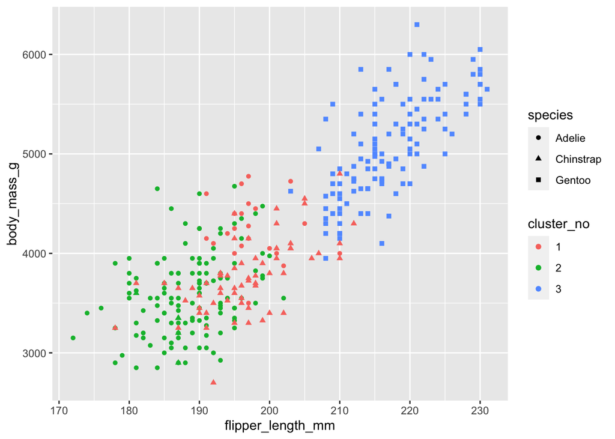

```r
# Bind the cluster number to the original data used for clustering, so that we can see what cluster each penguin is assigned to
penguins_cl <- data.frame(penguins_complete, cluster_no = factor(penguins_km$cluster))

# Plot flipper length versus body mass, indicating which cluster each penguin is assigned to (but also showing the actual species):
ggplot(penguins_cl) +
  geom_point(aes(x = flipper_length_mm,
                 y = body_mass_g,
                 color = cluster_no,
                 shape = species))
```

```r
# On your own: do the same, plotting bill dimensions and mapping species & cluster number to the point shape and color aesthetics:

# MAKE
# YOUR
# GRAPH
# HERE
```

What do we see from this graph?

We see that a lot of gentoos are in Cluster 3, a lot of Adelies are in Cluster 2, and A lot of chinstraps are in Cluster 1…but what are the actual counts? Let’s find them:

```r
# Find the counts of each species assigned to each cluster, then pivot_wider() to make it a contingency table:
penguins_cl %>%
  count(species, cluster_no) %>%
  pivot_wider(names_from = cluster_no, values_from = n) %>%
  rename('Cluster 1' = '1', 'Cluster 2' = '2', 'Cluster 3' = '3')
```

```
## # A tibble: 3 x 4
##   species   `Cluster 1` `Cluster 2` `Cluster 3`
##   <fct>           <int>       <int>       <int>
## 1 Adelie             24         127          NA
## 2 Chinstrap          63           5          NA
## 3 Gentoo             NA          NA         123
```

Takeaway: as we see from the graph, *most* chinstraps in Cluster 1, and *most* Adelies in Cluster 2, and *all* Gentoos are in Cluster 3 by k-means clustering. So this actually does a somewhat decent job of splitting up the three species into different clusters, with some overlap in Cluster 1 between Adelies & chinstraps, which is consistent with what we observed in exploratory data visualization.

That’s your intro to k-means clustering with penguins!

### Part 2. Cluster analysis: hierarchical

In this section, you’ll be performing hierarchical cluster analysis (& making dendrograms) in R. You should have already watched the Week 8 lecture to understand agglomerative versus divisive clustering, as well as differences in linkages (complete, single, average).

We will use the `stats::hclust()` function for agglomerative hierarchical clustering, using WorldBank environmental data (simplified), wb_env.csv.

#### Read in the data, & simplify

Here, we’ll read in the WorldBank environmental data (simplified), and keep only the top 20 GHG emitters for this dataset.

```r
# Get the data
wb_env <- read_csv("wb_env.csv")
# Make sure to take a look at the data:
# View(wb_env)

# Only keep top 20 greenhouse gas emitters (for simplifying visualization here...)
wb_ghg_20 <- wb_env %>%
  arrange(-ghg) %>%
  head(20)
```

#### Scale the data

```r
# Scale the numeric variables (columns 3:7)
wb_scaled <- wb_ghg_20 %>%
  select(3:7) %>%
  scale()


# Update to add rownames (country name) from wb_ghg_20
rownames(wb_scaled) <- wb_ghg_20$name

# Check the outcome with View(wb_scaled) - see that the rownames are now the country name (this is useful for visualizing)
```

Great, now we have a simplified, scaled version of the numeric variables, with rownames containing the county name.

#### Find the Euclidean distances

Use the `stats::dist()` function to find the Euclidean distance in multivariate space between the different observations (countries):

```r
# Compute dissimilarity values (Euclidean distances):
euc_distance <- dist(wb_scaled, method = "euclidean")

# Check out the output:
# View(euc_distance)
```

Note: so like you saw in lecture, you *could* manually create the dendrogram using those distances! But it would take a pretty long time, so instead…

#### Perform hierarchical clustering by complete linkage with `stats::hclust()`

The `stats::hclust()` function performs hierarchical clustering, given a dissimilarity matrix (our matrix of euclidean distances), using a linkage that you specify.

Here, let’s use complete linkage (recall from lecture: clusters are merged by the smallest *maximum* distance between two observations in distinct clusters).

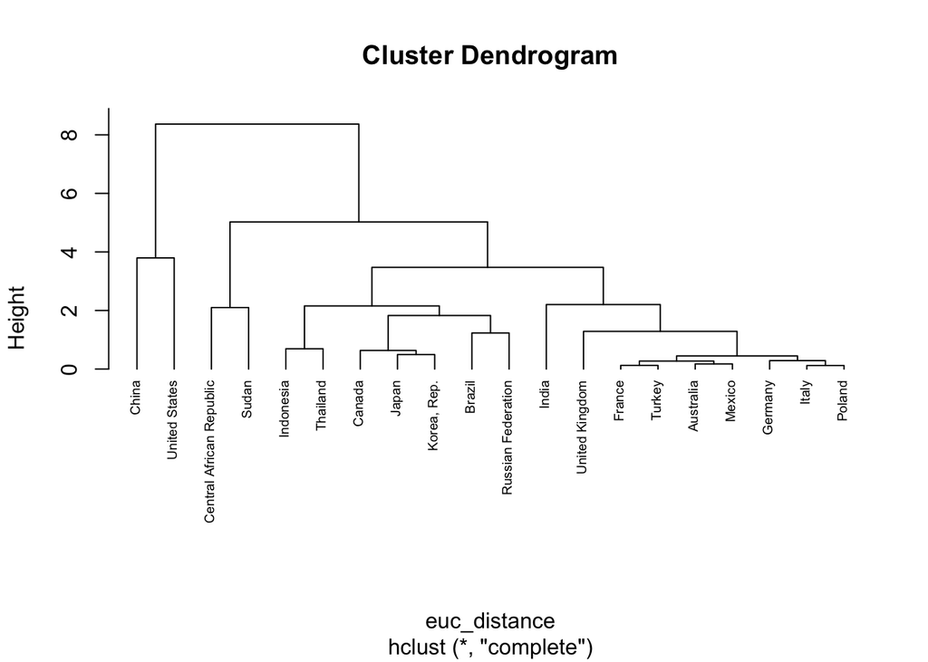

```r
# Hierarchical clustering (complete linkage)
hc_complete <- hclust(euc_distance, method = "complete" )

# Plot it (base plot):
plot(hc_complete, cex = 0.6, hang = -1)
```

### Now let’s do it by single linkage & compare

Let’s update the linkage to single linkage (recall from lecture: this means that clusters are merged by the *smallest* distance between observations in separate clusters):

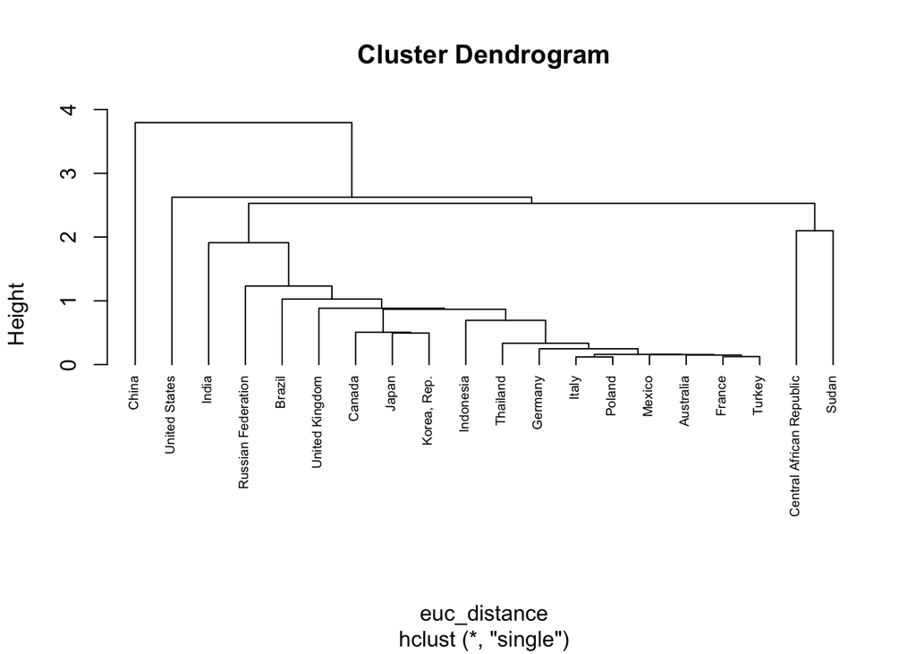

```r
# Hierarchical clustering (single linkage)
hc_single <- hclust(euc_distance, method = "single" )

# Plot it (base plot):
plot(hc_single, cex = 0.6, hang = -1)
```

We see that it is a bit different when we change the linkage! But how different?

#### Make a tanglegram to compare dendrograms

Let’s make a **tanglegram** to compare clustering by complete and single linkage! We’ll use the `dendextend::tanglegram()` function to make it.

First, we’ll convert to class `dendrogram`, then combine them into a list:

```r
# Convert to class dendrogram
dend_complete <- as.dendrogram(hc_complete)
dend_simple <- as.dendrogram(hc_single)
```

Cool, now make a tanglegram:

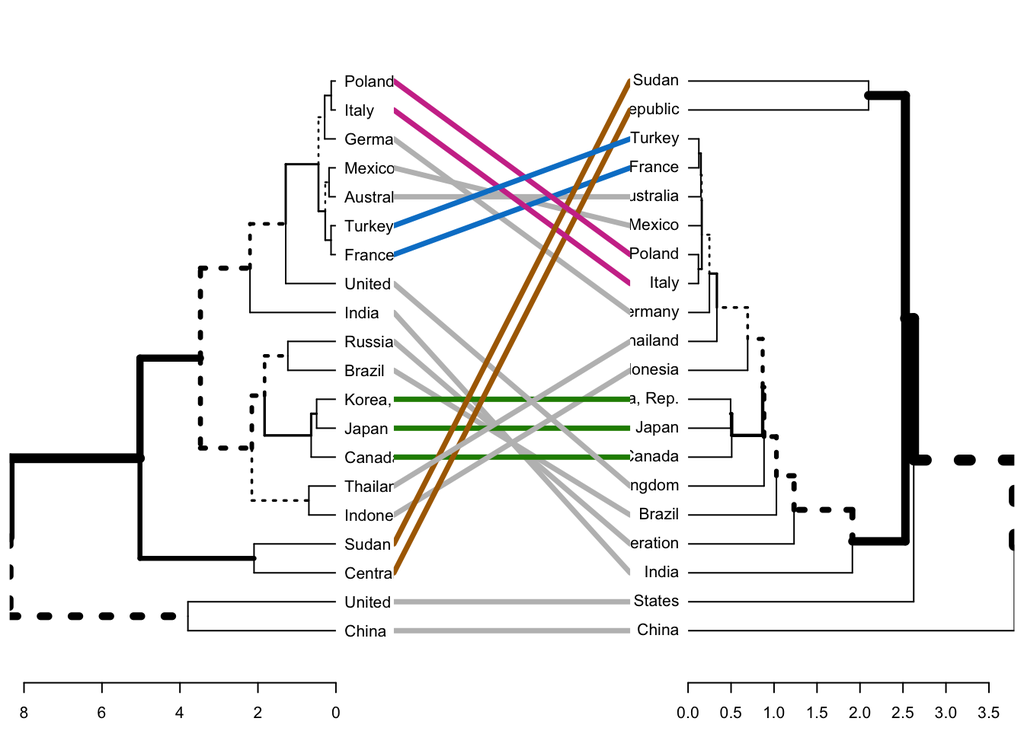

```r
# Make a tanglegram
tanglegram(dend_complete, dend_simple)
```

That allows us to compare how things are clustered by the different linkages!

#### Want to plot your dendrogram with ggplot instead? Me too.

Here’s how you can make your dendrogram with `ggplot` (here, I’ll use the complete linkage example stored as `hc_complete`) using `ggdendrogram()`, a `ggplot` wrapper:

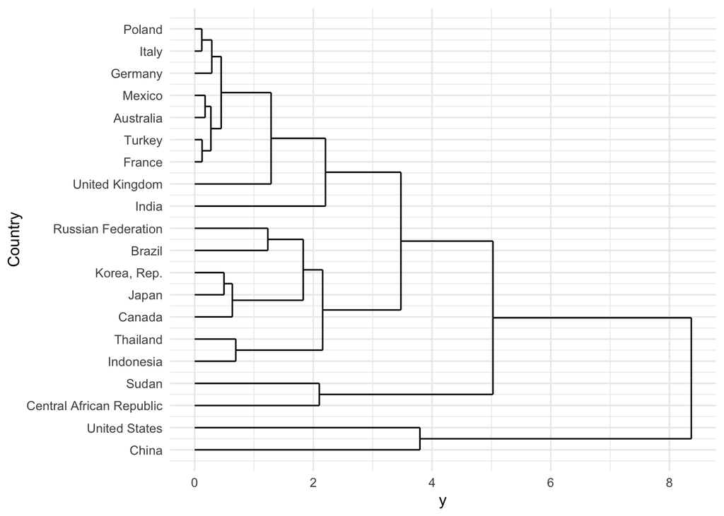

```r
ggdendrogram(hc_complete,
             rotate = TRUE) +
  theme_minimal() +
  labs(x = "Country")
```

```r
# COOL. Then you can customize w/ usual ggplot tools.
```

## End Week 8 lab